# R Assignment 2

Abbie Raza (1482784)

- necessary libraries

```r
library(dplyr)
```

```r
library(descr)
library(DescTools)
library(ggplot2)
library(survey)
```

#### 1. You’re a researcher who is interested in how workers have been doing over the past five years. Specifically, you’re interested in the relationship between education (X) and earnings (Y). You’re planning on studying this relationship by looking at data for employed workers with earnings from the Labour Force Survey. Start by reading-in your dataset.

```r
d1 <- read.csv("LFS_July17_21.csv", header = TRUE)
summary(d1$HRLYEARN)
```

```
##    Min. 1st Qu.  Median    Mean 3rd Qu.    Max.
##   3.136  17.198  24.387  28.144  35.613 125.490
```

```r
table(d1$EDUC)
```

```
##
##    0    1    2    3    4    5    6
##  369 2036 4715 1678 9118 4362 1808
```

#### 2. Recode the following variables to help prepare for you analyses:

1. Recode hourly earnings(HRLYEARN) into an ordinal variable defined by quintiles (HRLYEARN2)

```r
d1$HRLYEARN2 <- rep(0, length(d1$HRLYEARN))
d1$HRLYEARN2[d1$HRLYEARN < quantile(d1$HRLYEARN, 0.2)] <- "quintile 1"
d1$HRLYEARN2[d1$HRLYEARN >= quantile(d1$HRLYEARN, 0.2) & d1$HRLYEARN < quantile(d1$HRLYEARN, 0.4)] <- "quintile 2"
d1$HRLYEARN2[d1$HRLYEARN >= quantile(d1$HRLYEARN, 0.4) & d1$HRLYEARN < quantile(d1$HRLYEARN, 0.6)] <- "quintile 3"
d1$HRLYEARN2[d1$HRLYEARN >= quantile(d1$HRLYEARN, 0.6) & d1$HRLYEARN < quantile(d1$HRLYEARN, 0.8)]<- "quintile 4"
d1$HRLYEARN2[d1$HRLYEARN >= quantile(d1$HRLYEARN, 0.8)] <- "quintile 5"

d1$HRLYEARN2 <- factor(d1$HRLYEARN2,
                       levels = c("quintile 1", "quintile 2",
                                  "quintile 3", "quintile 4", "quintile 5"))
table(d1$HRLYEARN2)
```

```
##
## quintile 1 quintile 2 quintile 3 quintile 4 quintile 5
##       4654       4829       4939       4846       4818
```

2. Recode highest educational attainment (EDUC) to indicate whether the respondent completed at least a Bachelor’s degree (BAPLUS)

```r
d1$BAPLUS <- ifelse(d1$EDUC > 4, "Bachelor's", "No Bachelor's")
table(d1$BAPLUS)
```

```
##
##    Bachelor's No Bachelor's
##          6170         17916
```

3. Recode highest educational attainment (EDUC) into an ordinal variable (EDUC2) with the following categories: Less than a high school degree; High school graduate; Some post secondary; post secondary certificate or diploma; Bachelor’s degree; and Above a Bachelor’s degree. Categories can be indicated by numbers or names.

```r
d1$EDUC2 <- rep(0,length(d1$EDUC))
d1$EDUC2[d1$EDUC >= 1] <- "Less than high school"
d1$EDUC2[d1$EDUC == 2] <- "High school graduate"
d1$EDUC2[d1$EDUC == 3] <- "Some Postsecondary"
d1$EDUC2[d1$EDUC == 4] <- "Post Secondary certificate or diploma"
d1$EDUC2[d1$EDUC == 5] <- "Bachelor's degree"
d1$EDUC2[d1$EDUC == 6] <- "Above Bachelor's degree"

d1$EDUC2 <- factor(d1$EDUC2,
                       levels = c("Less than high school", "High school graduate",
                                  "Some Postsecondary", "Post Secondary certificate or diploma",
                                  "Bachelor's degree","Above Bachelor's degree"))
table(d1$EDUC2)
```

```
##
##                 Less than high school                  High school graduate
##                                  2036                                  4715
##                    Some Postsecondary Post Secondary certificate or diploma
##                                  1678                                  9118
##                     Bachelor's degree               Above Bachelor's degree
##                                  4362                                  1808
```

#### 3. Do mean earnings per hour (HRLYEARN) differ between people with and without at least a Bachelor’s degree (BAPLUS)? Make sure to discuss and interpret all parts of your analysis.

(HINT: You’ll likely need to discuss confidence intervals, a t-test, and a boxplot to fully answer this question.)

- Null Hypothesis (H0): There is no difference between the hourly earnings of those with a bachelor’s degree and those without a bachelor’s degree
- Alternative Hypothesis (H1): There is a difference between the hourly earnings of those with a bachelor’s degree and those without a bachelor’s degree

```r
mean(d1$HRLYEARN[d1$BAPLUS == "Bachelor's"])
```

```
## [1] 36.29736
```

```r
mean(d1$HRLYEARN[d1$BAPLUS == "No Bachelor's"])
```

```
## [1] 25.33548
```

```r
tapply(d1$HRLYEARN, d1$BAPLUS, mean)
```

```
##    Bachelor's No Bachelor's
##      36.29736      25.33548
```

```r
t.test(HRLYEARN ~ factor(BAPLUS), d1)
```

```
##
##  Welch Two Sample t-test
##
## data:  HRLYEARN by factor(BAPLUS)
## t = 47.437, df = 8519.9, p-value < 2.2e-16
## alternative hypothesis: true difference in means between group Bachelor's and group No Bachelor's is not equal to 0
## 95 percent confidence interval:
##  10.50891 11.41486
## sample estimates:
##    mean in group Bachelor's mean in group No Bachelor's
##                    36.29736                    25.33548
```

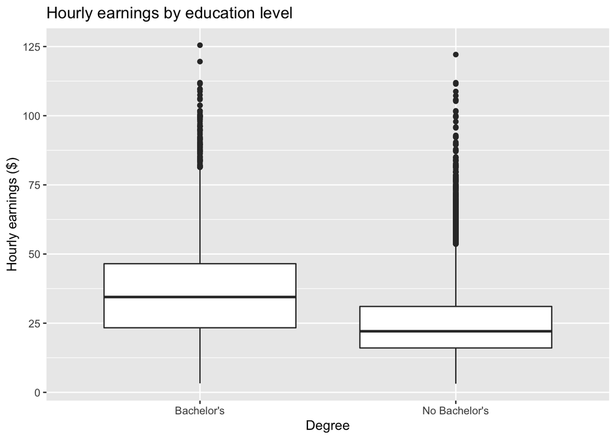

```r
ggplot(data = d1, aes(x=BAPLUS, y=HRLYEARN)) +
  geom_boxplot() +
      labs(y = "Hourly earnings ($)",
       x = "Degree",
       title = "Hourly earnings by education level",
       fill = "degree")
```

When viewing the boxplot, the median hourly earnings for those with at least a bachelor’s to be higher than those without a bachelors. Additionally, when comparing the middle 50% of hourly earning for both groups, there is a lot more variation with hourly earnings for those with bachelor’s degrees than those without a bachelor’s degrees. Symmetry for both box plots was not even, where the distance between the top 25% of earners from the median was larger than the distance between the lowest 25% and the median. Hence, both groups were skewed noticeably to the right.

The line defining the upper quartile for the group with at least a bachelor’s degree was higher than the line defining the upper quartile for the group with no bachelor’s degree. The same could be said about the line defining the lower quartile for both groups. What this tells us is that overall individuals typically are earning more if they hold at least a bachelor’s degree.

#### 4. Is there a relationship between hourly earnings measured in quintiles (HRLYEARN2) and highest level of education (EDUC2)? Make sure to discuss and interpret all parts of your analysis.

(HINT: You’ll likely need to bring in a bivariate table, a chi-squared test, a bar graph with a conditional distribution, and some measures of association to fully answer this question.)

```r
round(prop.table(table(d1$EDUC2, d1$HRLYEARN2), margin = 2)*100, 2)
```

```
##
##                                         quintile 1 quintile 2 quintile 3
##   Less than high school                      22.14      10.16       6.01
##   High school graduate                       29.19      25.96      20.24
##   Some Postsecondary                         13.62       9.33       6.70
##   Post Secondary certificate or diploma      24.45      37.96      46.85
##   Bachelor's degree                           8.16      13.10      15.56
##   Above Bachelor's degree                     2.44       3.49       4.63
##
##                                         quintile 4 quintile 5
##   Less than high school                       3.71       1.81
##   High school graduate                       16.45       8.22
##   Some Postsecondary                          4.23       1.94
##   Post Secondary certificate or diploma      45.50      36.47
##   Bachelor's degree                          21.76      32.70
##   Above Bachelor's degree                     8.35      18.86
```

```r
CrossTable(d1$EDUC2, d1$HRLYEARN2) # incorporate measures of association
```

```
##    Cell Contents
## |-------------------------|
## |                       N |
## | Chi-square contribution |
## |           N / Row Total |
## |           N / Col Total |
## |         N / Table Total |
## |-------------------------|
##
## ================================================================================
##              d1$HRLYEARN2
## d1$EDUC2     quintil 1   quintil 2   quintil 3   quintil 4   quintil 5     Total
## --------------------------------------------------------------------------------
## Lss t h s          998         480         293         178          87      2036
##                964.699      13.605      37.721     133.090     256.756
##                  0.490       0.236       0.144       0.087       0.043     0.086
##                  0.221       0.102       0.060       0.037       0.018
##                  0.042       0.020       0.012       0.008       0.004
## --------------------------------------------------------------------------------
## Hgh sch g         1316        1227         987         790         395      4715
##                196.641      87.950       0.314      28.397     328.416
##                  0.279       0.260       0.209       0.168       0.084     0.199
##                  0.292       0.260       0.202       0.165       0.082
##                  0.055       0.052       0.042       0.033       0.017
## --------------------------------------------------------------------------------
## Sm Pstscn          614         441         327         203          93      1678
##                272.954      34.005       0.944      55.040     179.334
##                  0.366       0.263       0.195       0.121       0.055     0.071
##                  0.136       0.093       0.067       0.042       0.019
##                  0.026       0.019       0.014       0.009       0.004
## --------------------------------------------------------------------------------
## P S c o d         1102        1794        2285        2185        1752      9118
##                229.812       0.289      89.672      62.202       4.876
##                  0.121       0.197       0.251       0.240       0.192     0.384
##                  0.244       0.380       0.469       0.455       0.365
##                  0.046       0.076       0.096       0.092       0.074
## --------------------------------------------------------------------------------
## Bchlr's d          368         619         759        1045        1571      4362
##                256.443      72.020      21.223      29.650     534.883
##                  0.084       0.142       0.174       0.240       0.360     0.184
##                  0.082       0.131       0.156       0.218       0.327
##                  0.016       0.026       0.032       0.044       0.066
## --------------------------------------------------------------------------------
## Abv Bc' d          110         165         226         401         906      1808
##                158.865     105.841      57.165       3.334     795.596
##                  0.061       0.091       0.125       0.222       0.501     0.076
##                  0.024       0.035       0.046       0.084       0.189
##                  0.005       0.007       0.010       0.017       0.038
## --------------------------------------------------------------------------------
## Total             4508        4726        4877        4802        4804     23717
##                  0.190       0.199       0.206       0.202       0.203
## ================================================================================
```

```r
GoodmanKruskalGamma(d1$EDUC2, d1$HRLYEARN2)# measure of association
```

```
## [1] 0.4287677
```

```r
chisq.test(d1$EDUC2, d1$HRLYEARN2)
```

```
##
##  Pearson's Chi-squared test
##
## data:  d1$EDUC2 and d1$HRLYEARN2
## X-squared = 5011.7, df = 20, p-value < 2.2e-16
```

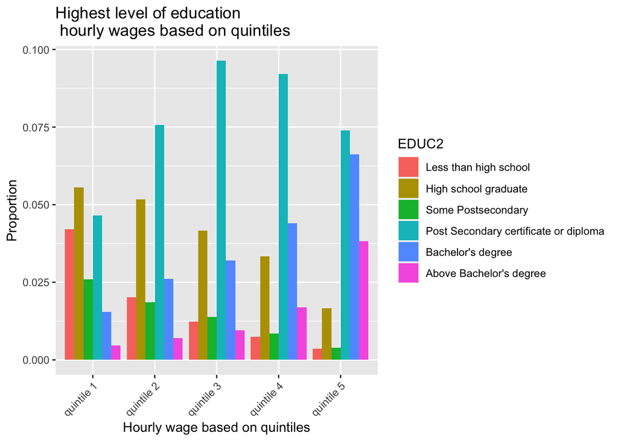

```r
# bar plot with conditional distribution
# conditional distribution of HRLYEARN2 based on EDUC2
ggplot(data = subset(d1, !is.na(EDUC2)), aes(x = HRLYEARN2,y = ((..count..)/sum(..count..)), fill = EDUC2)) + geom_bar(position = "dodge") +labs(x = "Hourly wage based on quintiles",
y = "Proportion",
title = "Highest level of education \n hourly wages based on quintiles") +
theme(axis.text.x = element_text(angle = 45, hjust = 1))
```

There does seem to be a general trend when it comes to the dispersion of individuals within each quintile group and their highest level of education. For instance, people who have less than high school education or have their high school diploma make up a majority of the first quintile (the bottom 20%) of earners, whereas we see these two groups become less and less common in the higher quintile ranges. In quintile 5, these two groups make up roughly 10% for quintile 5. People who have completed some post secondary also follow the same trend but not at the same extreme as those with a high school diploma or less.

The opposite can be said for people with a bachelor’s degree or above. People with a bachelor’s degree or above make up the bulk of quintile 5, making them the highest earners per hour at 51.6%. in other words, the fifth quintile is majority people with a bachelor’s degree or above.

Those with a post secondary certificate or diploma seem to be quite evenly spaced out, ranging from 24% to 47%. This group makes up the majority of earners in the third quintile, at 46.85%. At the 2,3,4, and 5th quintiles they consistently make up the largest majority as a single group.

χ2 = 5011.7, p value < 2.2 x 10^(-16) with df = 20, making the relationship between EDUC2 and HRLYEARN2 statistically significant. We can be sure of this conclusion with 95% confidence.

#### 5. Extra Credit: This question is optional. If you answer the question correctly you can earn extra points to make up for lost points on other questions, but you cannot earn more than 100% total on the assignment.

Answer question #3 with data that account for complex sampling and incorporate the survey weights (FINALWT). Do your findings differ after incorporating survey weights? (HINT: You’ll likely need to use functions like svyby(), svymean(), and svyttest() to answer this question.)

- 3. Do mean earnings per hour (HRLYEARN) differ between people with and without at least a Bachelor’s degree (BAPLUS)? Make sure to discuss and interpret all parts of your analysis.

```r
d1w <- svydesign(ids = ~1, data = d1, weights = d1$FINALWT)
summary(d1w)
```

```
## Independent Sampling design (with replacement)
## svydesign(ids = ~1, data = d1, weights = d1$FINALWT)
## Probabilities:
##      Min.   1st Qu.    Median      Mean   3rd Qu.      Max.
## 0.0003167 0.0023697 0.0053191 0.0063287 0.0085470 0.1250000
## Data variables:
##  [1] "REC_NUM"   "FINALWT"   "AGYOWNK"   "LFSSTAT"   "PROV"      "CMA"
##  [7] "AGE_12"    "SEX"       "MARSTAT"   "EDUC"      "IMMIG"     "EFAMTYPE"
## [13] "HRLYEARN"  "COWMAIN"   "PERMTEMP"  "FIRMSIZE"  "SURVYEAR"  "UNION"
## [19] "NOC_10"    "UTOTHRS"   "TENURE"    "HRSTOT"    "HRLYEARN2" "BAPLUS"
## [25] "EDUC2"
```

```r
svymean(~HRLYEARN, design = d1w) # survey coefficient and standard error
```

```
##            mean     SE
## HRLYEARN 29.032 0.1397
```

```r
mean(d1$HRLYEARN) # non-weighted mean
```

```
## [1] 28.14353
```

```r
svyquantile(~HRLYEARN, d1w, c(0.5), ci = TRUE) # survey median
```

```
## $HRLYEARN
##     quantile   ci.2.5  ci.97.5        se
## 0.5       25 24.89736 25.40015 0.1282584
##
## attr(,"hasci")
## [1] TRUE
## attr(,"class")
## [1] "newsvyquantile"
```

```r
median(d1$HRLYEARN) # median when sample is not weighted
```

```
## [1] 24.38727
```

```r
svyby(~HRLYEARN, ~BAPLUS, d1w, svymean)
```

```
##                      BAPLUS HRLYEARN        se
## Bachelor's       Bachelor's 36.85993 0.3089491
## No Bachelor's No Bachelor's 25.58670 0.1307660
```

```r
svyttest(HRLYEARN~BAPLUS, d1w)
```

```
##
##  Design-based t-test
##
## data:  HRLYEARN ~ BAPLUS
## t = -33.603, df = 24084, p-value < 2.2e-16
## alternative hypothesis: true difference in mean is not equal to 0
## 95 percent confidence interval:
##  -11.93080 -10.61566
## sample estimates:
## difference in mean
##          -11.27323
```

t score = -33.603, where df = 24084, p < 2.2*10^(-16) The mean for this weighted survey is equal to 29.03. In other words, the weighted mean workers were earning was $29.03. The standard error of the mean is 0.1397 which indicates the extent the sample mean deviates from the population mean. In this case, we can conclude that the sample mean is fairly indicative of the population mean. The median non-weighted hourly wage is $24.39, which indicates that the distribution for the weighted distribution is slightly skewed to the right.

When breaking apart the two groups (bachelors s no bachelor’s), those who hold at least a bachelor’s degree earn significantly more on average per hour than those who do not. People with at least a bachelor’s degree can expect an average hourly salary of $36.86, while those without a bachelor’s degree could expect an average hourly salary of 25.59 dollars, which is closer to the weighted survey mean.

When conducting the survey t-test, the p value again was less than 2.2*10^(-16), which makes it less than the 0.05 critical value, hence, is significant.